# peng

Autogenerated data summary from dataReporter

2021-09-16 20:11:48

# Data report overview

The dataset examined has the following dimensions:

| Feature | Result |
| --- | --- |
| Number of observations | 344 |
| Number of variables | 8 |

### Checks performed

The following variable checks were performed, depending on the data type of each variable:

|  | character | factor | labelled | haven labelled | numeric | integer | logical | Date |
| --- | --- | --- | --- | --- | --- | --- | --- | --- |
| Identify miscoded missing values | × | × | × | × | × | × |  | × |
| Identify prefixed and suffixed whitespace | × | × | × | × |  |  |  |  |
| Identify levels with < 6 obs. | × | × | × | × |  |  |  |  |
| Identify case issues | × | × | × | × |  |  |  |  |
| Identify misclassified numeric or integer variables | × | × | × | × |  |  |  |  |
| Identify outliers |  |  |  |  | × | × |  | × |

Please note that all numerical values in the following have been rounded to 2 decimals.

# Summary table

|  | Variable class | # unique values | Missing observations | Any problems? |
| --- | --- | --- | --- | --- |
| species | factor | 3 | 0.00 % |  |
| island | factor | 3 | 0.00 % |  |
| bill_length_mm | numeric | 165 | 0.58 % | × |
| bill_depth_mm | numeric | 81 | 0.58 % |  |
| flipper_length_mm | integer | 56 | 0.58 % | × |
| body_mass_g | integer | 95 | 0.58 % | × |
| sex | factor | 3 | 3.20 % |  |
| year | integer | 3 | 0.00 % |  |

# Variable list

## species

| Feature | Result |
| --- | --- |
| Variable type | factor |
| Number of missing obs. | 0 (0 %) |
| Number of unique values | 3 |
| Mode | “Adelie” |
| Reference category | Adelie |

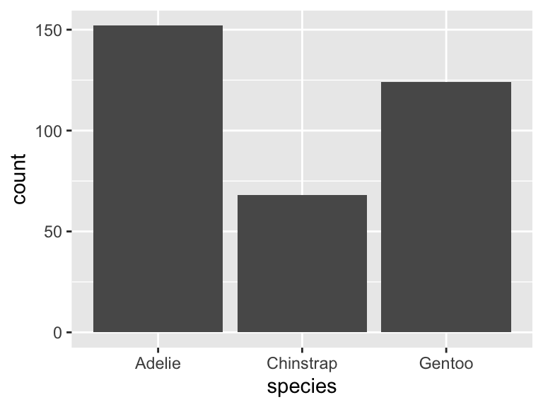

## island

| Feature | Result |
| --- | --- |
| Variable type | factor |
| Number of missing obs. | 0 (0 %) |
| Number of unique values | 3 |
| Mode | “Biscoe” |
| Reference category | Biscoe |

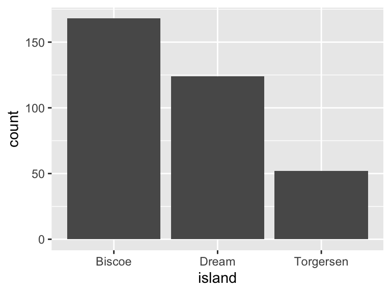

## bill_length_mm

| Feature | Result |
| --- | --- |
| Variable type | numeric |
| Number of missing obs. | 2 (0.58 %) |
| Number of unique values | 164 |
| Median | 44.45 |
| 1st and 3rd quartiles | 39.23; 48.5 |
| Min. and max. | 32.1; 59.6 |

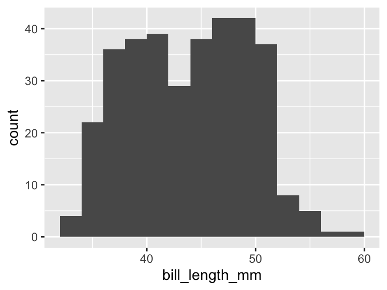

- Note that the following possible outlier values were detected: "58", "59.6".

## bill_depth_mm

| Feature | Result |
| --- | --- |
| Variable type | numeric |
| Number of missing obs. | 2 (0.58 %) |
| Number of unique values | 80 |
| Median | 17.3 |
| 1st and 3rd quartiles | 15.6; 18.7 |
| Min. and max. | 13.1; 21.5 |

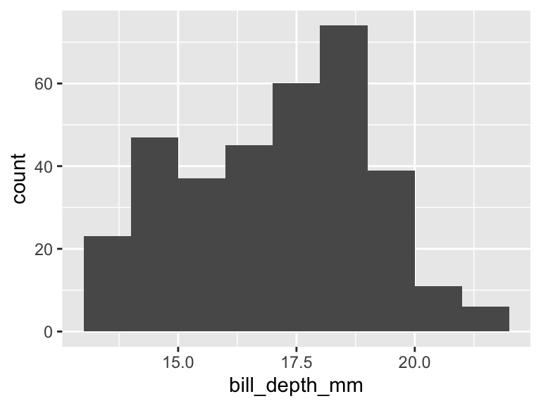

## flipper_length_mm

| Feature | Result |
| --- | --- |
| Variable type | integer |
| Number of missing obs. | 2 (0.58 %) |
| Number of unique values | 55 |
| Median | 197 |
| 1st and 3rd quartiles | 190; 213 |
| Min. and max. | 172; 231 |

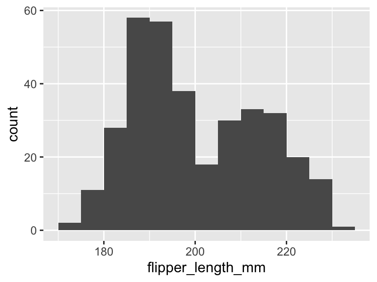

- Note that the following possible outlier values were detected: "172", "174", "176", "178", "179", "180".

## body_mass_g

| Feature | Result |
| --- | --- |
| Variable type | integer |
| Number of missing obs. | 2 (0.58 %) |
| Number of unique values | 94 |
| Median | 4050 |
| 1st and 3rd quartiles | 3550; 4750 |
| Min. and max. | 2700; 6300 |

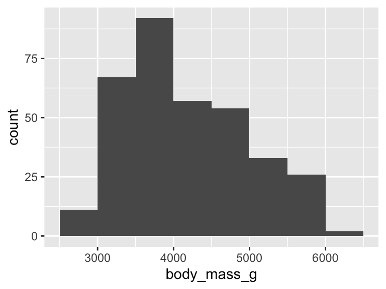

- Note that the following possible outlier values were detected: "2700".

## sex

| Feature | Result |
| --- | --- |
| Variable type | factor |
| Number of missing obs. | 11 (3.2 %) |
| Number of unique values | 2 |
| Mode | “male” |
| Reference category | female |

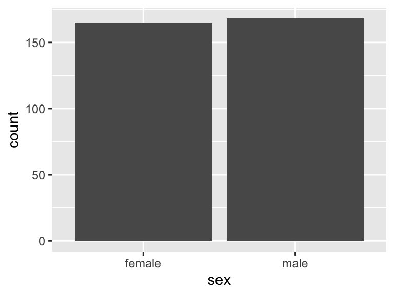

## year

- Note that this variable is treated as a factor variable below, as it only takes a few unique values.

| Feature | Result |
| --- | --- |
| Variable type | integer |
| Number of missing obs. | 0 (0 %) |
| Number of unique values | 3 |
| Mode | “2009” |
| Reference category | 2007 |

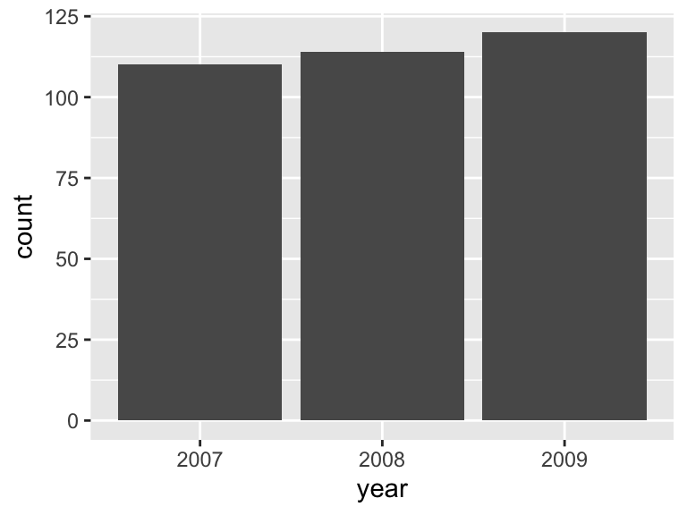

Report generation information:

- Created by: Niloufar Pourshir (username: `niloufar`).
- Report creation time: Thu Sep 16 2021 20:11:48
- Report was run from directory: `/Users/niloufar/Desktop/Datasets/Bike-Sharing-Dataset`
- dataReporter v1.0.0 [Pkg: 2020-12-14 from CRAN (R 4.1.0)]
- R version 4.1.1 (2021-08-10).
- Platform: x86_64-apple-darwin17.0 (64-bit)(macOS Big Sur 11.3.1).
- Function call: `dataReporter::makeDataReport(data = peng, replace = TRUE)`